# **Proyecto - Clasificación y Prueba de Hipótesis: Predicción de Cancelación de Reserva de Hotel**

#### **Pregunta 6.5: ¿Cuáles son algunas características importantes basadas en el árbol de decisiones ajustado? (1 Punto)**

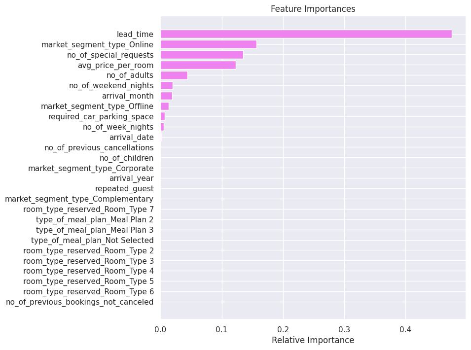

```python
# Remove _________ and complete the code

# Importance of features in the tree building

importances = estimator.feature_importances_
indices = np.argsort(importances)

plt.figure(figsize=(8, 8))
plt.title("Feature Importances")
plt.barh(range(len(indices)), importances[indices], color="violet", align="center")
plt.yticks(range(len(indices)), [feature_names[i] for i in indices])
plt.xlabel("Relative Importance")
plt.show()
```

**Escriba sus respuestas aquí**

Observamos las características más importantes que influyen sobre la variable predictora de cancelación de reserva: 1) N° días entre la fecha de reserva y llegada 2) Designación del segmento de mercado 3) Número total de solicitudes especiales realizadas por el cliente

### **Pregunta 7: Bosque aleatorio (4 puntos)**

#### **Pregunta 7.1: Construya un modelo de bosque aleatorio (1 punto)**

```python
# Remove _________ and complete the code

rf_estimator = RandomForestClassifier( random_state = 1)

rf_estimator.fit(X_train, y_train)
```

```
RandomForestClassifier(random_state=1)
```

#### **Pregunta 7.2: Compruebe el rendimiento del modelo en los datos de entrenamiento y prueba (2 puntos)**

```
              precision    recall  f1-score   support

           0       0.99      1.00      1.00     17073
           1       1.00      0.99      0.99      8319

    accuracy                           0.99     25392
   macro avg       0.99      0.99      0.99     25392
weighted avg       0.99      0.99      0.99     25392
```

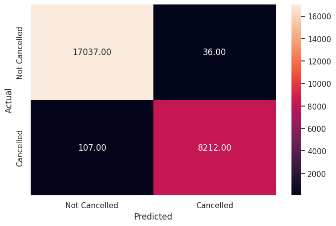

```python
# Remove _________ and complete the code

y_pred_train_rf = rf_estimator.predict(X_train)

metrics_score(y_train, y_pred_train_rf)
```

**Escriba sus respuestas aquí**

Casi 0 errores en el conjunto de entrenamiento, cada muestra ha sido clasificada correctamente. El modelo se ha desempeñado muy bien en el set de entrenamiento.

```
              precision    recall  f1-score   support

           0       0.91      0.95      0.93      7317
           1       0.88      0.80      0.84      3566

    accuracy                           0.90     10883
   macro avg       0.90      0.88      0.88     10883
weighted avg       0.90      0.90      0.90     10883
```

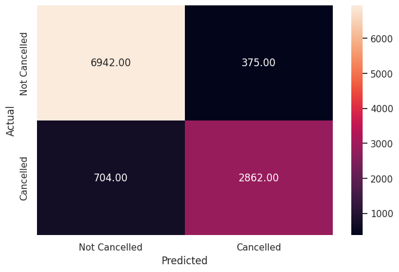

```python
# Remove _________ and complete the code

y_pred_test_rf = rf_estimator.predict(X_test)
metrics_score(y_test, y_pred_test_rf)
```

**Escriba sus respuestas aquí**

El clasificador Random Forest esta sobreajustado.

#### **Pregunta 7.3: ¿Cuáles son algunas características importantes basadas en Random Forest? (1 Punto)**

Comprobemos la importancia de las características del Random Forest

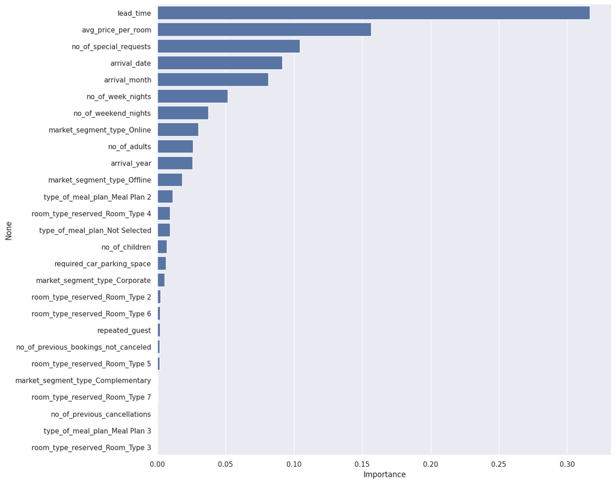

```python
# Remove _________ and complete the code

importances = rf_estimator.feature_importances_

columns = X.columns

importance_df = pd.DataFrame(importances, index = columns, columns = ['Importance']).sort_values(by = 'Importance', ascending = False)

plt.figure(figsize = (13, 13))

sns.barplot(x=importance_df.Importance, y=importance_df.index)
```

**Escriba sus respuestas aquí**

Random Forest determina que las características más importantes son el número de días entre la fecha de reserva y llegada, el precio promedio diario por reserva y el número especial de requerimientos.

Mientras más alto es el número de días entre la fecha de reserva y llegada, es más probable que el cliente cancele la reserva. Lo anterior puede deberse a que por ejemplo si un cliente reserva con un año de anticipación, durante ese período es más probable que surjan situaciones personales que provoquen que cancele la reserva.

El número de requerimientos especiales tambien influye, mientras menos requerimientos hayan en la reserva es más probable que un cliente cancele la reserva. Esto puede comprobarse en el diagrama de correlación donde existe relación negativa entre ambas variables

### **Pregunta 8: Concluya CUATRO puntos clave para las recomendaciones empresariales (4 puntos)**

**Escriba sus respuestas aquí**

1) El modelo que mejores resultados demostró fue el ajuste de hiperparámetros usando GridSearch CV con un recall de 68% y precisión de 82%. Este modelo tuvo la mejor precisión de todos los modelos sin considerar aquellos que resultaron con sobreajuste como árbol de regresión y random forest. El recall de este modelo no es el más alto, sin embargo, los otros modelos lograron un recall mayor debido al optimal threshold cuyo valor puede llegar a subestimarse o sobreajustarse castigando la precisión.

2) La principal variable que influye sobre las cancelaciones de reserva y que quedo demostrado en el diagrama de correlación y en las características del árbol y random forest es el número de días entre las fechas de reserva y llegada. Se podría implementar una política entre días de reserva y llegada con un límite no mayor a 1 año, 9 meses o hasta 6 meses para así reducir la tasa de cancelación puesto que quedo demostrado que mientras más grande sea la diferencia de días, es más probable que haya cancelación.

3) Se debiese de quitar la restricción del número de requerimientos adicionales y transformar el hotel en uno que ofrezca como mínimo 3 lujos de los que incluyen estos requerimientos. Es más probable que un cliente cancele la reserva cuando tiene la menor cantidad de requerimiento especiales, quizás se deba porque que encontró un mejor lugar donde alojarse o porque encontró caro el hotel al tener 0 o solo 1 requerimiento adicional.

4) Las mayores tasas de cancelación ocurren en el canal online en market_segment_type, implementar una estrategia de marketing a nivel crm (client relationship managment) puede ayudar a retener a estos clientes para que no incurran en la cancelación: oferta de cupones, precios ahorros (sobre todo porque en este canal el precio promedio de reserva es el más alto por sobre los demás market_segment_type), implementación de canales digitales más personalizados como sms o whatsapps pueden apoyar a revertir la situación y así bajar la tasa de cancelación.

## **¡Feliz aprendizaje!**

```python
#!jupyter nbconvert --to html "PROYECTO_2_ELA_MIT(5).ipynb"
```